# MELTING POTES

Task A : SDM-NEO Data analysis

Author

Amélie Lehuen

Published

January 1, 2022

# 1 Dataset description for M&M

All data treatment has been conducted with R version 4.2.2 (2022-10-31 ucrt) except for MARS3D pre-treatment on Matlab 2019a. Significance levels are tagged for p < .0001 with “****”, p < .001 with “***”, p < .01 with “**”, p < .05 with “*”.

## 1.1 Areas map

The Seine estuary has been studied regarding several historically known areas that have either habitat or communities differences. These areas are mainly mudflats and subtidal areas, are represented in Figure 1.

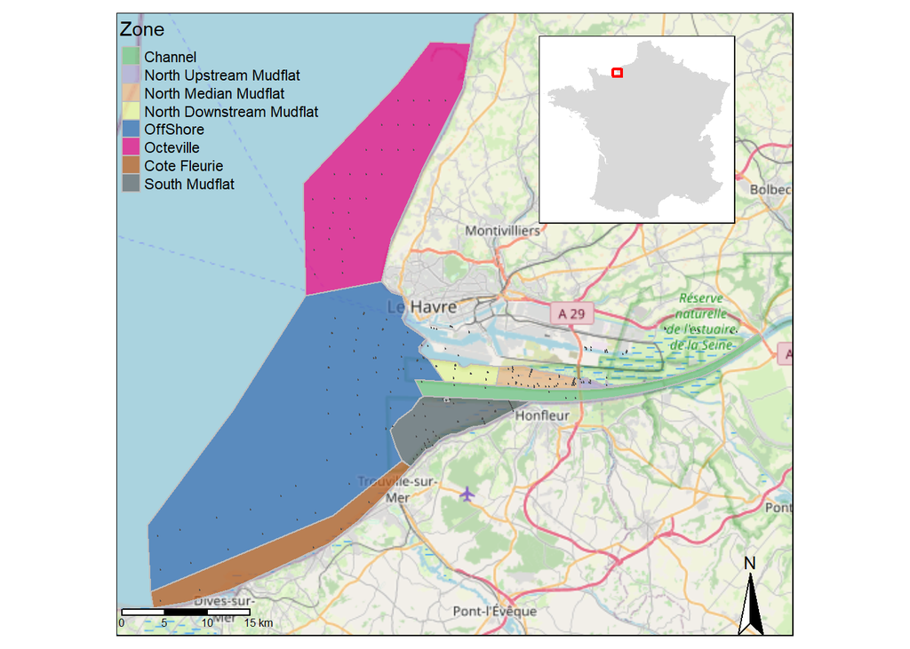

Figure 1: Maps of habitats areas defined for the study

## 1.2 Biologic dataset

The raw data (n= 50,948) has been harmonised and grouped to obtain a single database of 31,079 observations, and 187 sampling stations in total (with some variation in coordinates from year to year), with an average of 87 stations per campaign, occurred mainly in the months of Oct, Sep, Nov. Along the all period covered by the dataset, from 2000 to 2019, discarding before 2000 (too few observations n=216), with 1 to 2 sampling campaigns per year, a series of 5-years periods has been defined, 2000-2005 the building of ‘Port 2000’ with high disruption in the estuary area; 2006-2010; 2011-2015; 2016-2019. 627 different species has been founded, and *C. edule* counts 543 observations. Focus for following treatment is made on mudflats only for their biologic relevance for *C. edule* (Cote Fleurie (n= 1), North Downstream Mudflat (n= 82), North Median Mudflat (n= 198), North Upstream Mudflat (n= 2), Octeville (n= 3), OffShore (n= 39), South Mudflat (n= 218)).

## 1.3 Cerastoderma edule data structure

With a closer look on the data for *C. edule*, it is represented in Figure 2 the differences of biomass [gAFDW/m²] regarding periods and areas. The observations are split into periods as 2000-2005 (n= 108), 2006-2010 (n= 155), 2011-2015 (n= 174), 2015-2019 (n= 106). They are seldom in North Upstream Mudflat, where the water are more brackish.

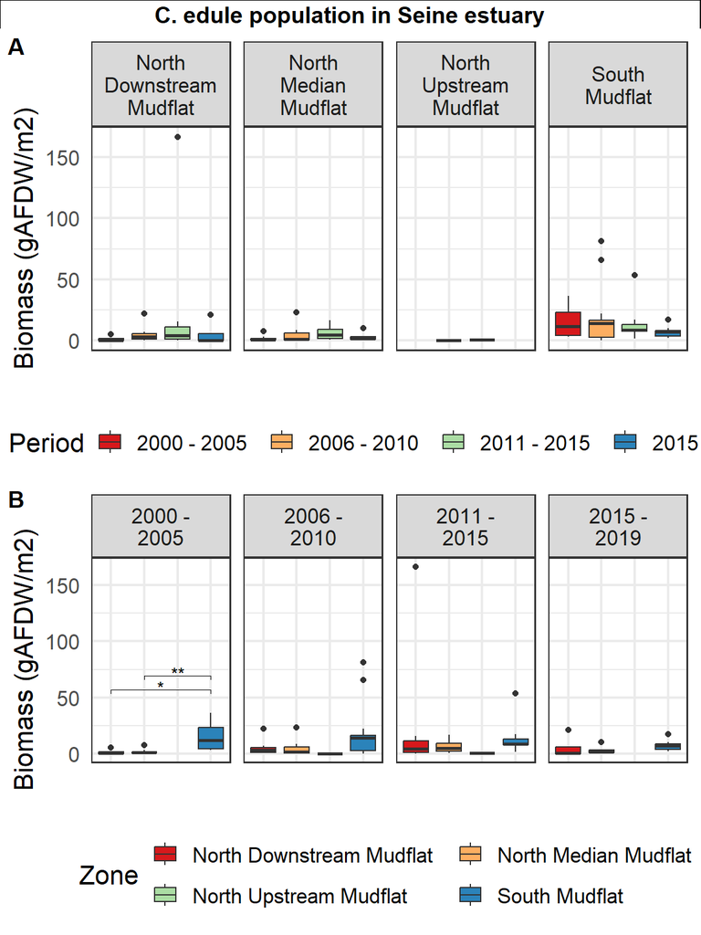

Figure 2: C. edule population biomass [gAFDW/m²] in the Seine estuary, by Period for eahc areas (A) and by areas for each Period (B) with significant differences

## 1.4 Abiotic dataset

All variables have been observed and a correlation study has been conducted to select the more pertinent factors and avoid autocorrelation between factors.

Models are built with two abiotic factors to increase their reliability. The couples tested are:

1. Current Speed daily max and Inundation time : to compare results with (Cozzoli et al. 2014), and these variables are easily retrieved with some high frequency measurement (COASTHF) . They have also a interest because they contains information on the position in the tidal area that could evolve with sea level rise and the hydrological conditions impact by the river flowrate change due to climate change even though they have a significant correlation (Corr = 0.56****)
2. Mud content and Bed shear stress: Those variables are determinant in a building of an erosion model such as MARS3D (Corr = -0.10*).
3. Temperature and Salinity daily range: These factors are easily measurable on high frequency also (Somlit). They are both bearing the climate change for the global temperature change and the evolution of the river regime that would impact the salinity profile of the estuary (Corr = 0.02 ).
4. Temperature and Inundation time : (Corr = 0.52****).

# 2 Results

## 2.1 SDM-NEO : Comparison of linear and nonlinear QR

The four couples of factors has been treated with the different ways of calculation : either linear with interaction, or non linear with bifactorial gaussian equation with the biomass as biologic response Figure 3.

### 2.1.1 2D visualisation

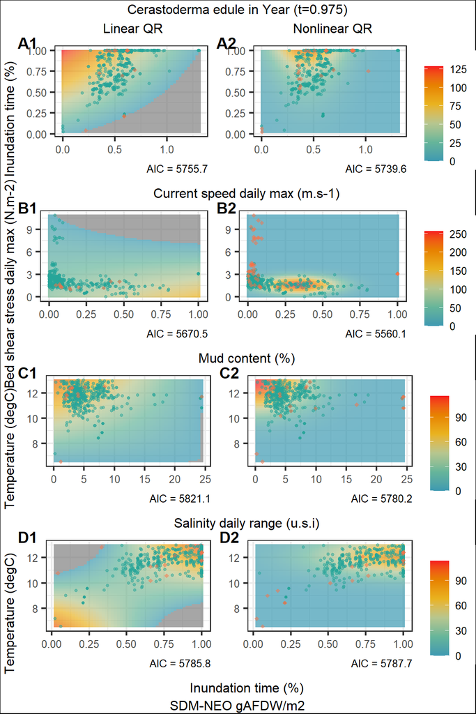

Figure 3: Selected factors couples models computed with linear with interaction (left, numbered 1) and nonlinear with gaussian equation (right numbered 2), the biologic response being the biomass in Ash Free Dry Weight per square meter

The same board of plots with density are in Figure 4. *can be put in supplementary data*

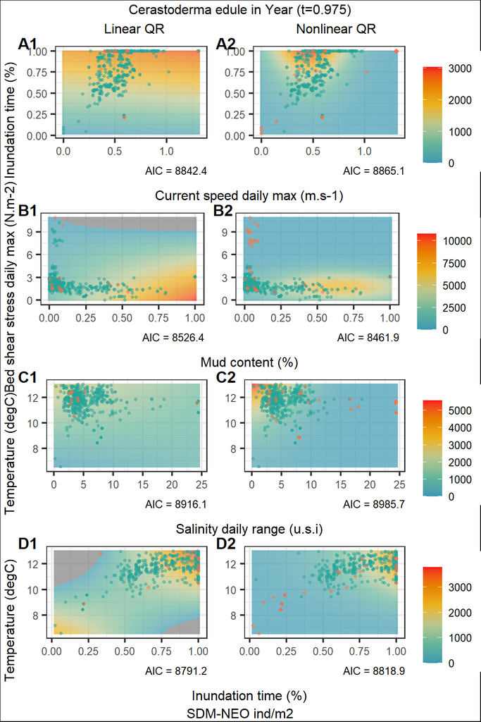

Figure 4: Selected factors couples models computed with linear with interaction (left, numbered 1) and nonlinear with gaussian equation (right numbered 2), the biologic response being the density in individuals per square meter

# 3 SDM-NEO Maps

## References

Cozzoli, Francesco, Menno Eelkema, Tjeerd J. Bouma, Tom Ysebaert, Vincent Escaravage, and Peter M. J. Herman. 2014. “A Mixed Modeling Approach to Predict the Effect of Environmental Modification on Species Distributions.” *PLoS ONE* 9 (2): e89131. https://doi.org/10.1371/journal.pone.0089131.